# EAS 508 Assignment 1– Sainath Aittla, UB ID: 50557807

```r
library(ISLR2)
library(ggplot2)
```

In case you need to write math expression, please use the quick tutorial as the reference: https://www1.cmc.edu/pages/faculty/aaksoy/latex/latexthree.html

# Question 1

[5 pts] Describe a situation or problem from your job, everyday life, current events, etc., for which a classification model would be appropriate. List some (up to 5) predictors that you might use.

**Solution to Question 1**

Let’s consider the problem of predicting customer churn for a subscription-based service, which is a common issue in the business world. Churn prediction involves identifying customers who are likely to cancel their subscriptions in the near future. By accurately predicting churn, companies can take proactive steps to retain customers, such as offering discounts, improving service quality, or addressing specific concerns.

**Prediction:** Predicting customer churn for a subscription-based service (e.g., streaming services, software-as-a-service platforms, etc.).

**Predictors:**

**Usage Activity:** The frequency and duration of the service usage can be a strong indicator of customer engagement and satisfaction. Customers who use the service less frequently or for shorter durations may be more likely to churn.

**Customer Support Interactions:** The number and nature of interactions with customer support can provide insights into customer satisfaction and potential issues. A high number of support tickets or complaints may indicate dissatisfaction, increasing the likelihood of churn.

**Subscription Length:** The duration for which a customer has been subscribed to the service. Longer-term customers might have a lower propensity to churn compared to newer customers, who might still be evaluating the service.

**Payment History:** Timeliness and regularity of payments can also serve as a predictor. Customers with late payments or irregular payment patterns may be experiencing dissatisfaction or financial issues, making them more likely to churn.

**Plan Type:** The type of subscription plan a customer has chosen could influence their likelihood to churn. For instance, customers on a premium plan might be more engaged and less likely to leave compared to those on basic or trial plans.

By leveraging these predictors, a **classification model can classify customers into those likely to churn and those likely to stay**, enabling targeted interventions to improve customer retention.

# Question 2.

[5 pts] What’s the main difference between supervised and unsupervised learning? Give one benefit and drawback for supervised and unsupervised learning, respectively.

**Solution to Question 2**

The main difference between supervised and unsupervised learning lies in the presence or absence of labeled data for training the model.

**Supervised Learning:** **Definition:** Supervised learning involves training a model on a labeled dataset, which means that each training example is paired with an output label. The model learns to predict the output from the input data.

**Benefit:** Since the model is trained with both input and output data, it can achieve high accuracy and is capable of making precise predictions on new, unseen data, provided the new data is similar to the training data.

**Drawback:** It requires a large amount of labeled data, which can be time-consuming and expensive to acquire. Labeling data accurately requires domain expertise, making it challenging for tasks where expert knowledge is scarce or expensive to obtain.

**Unsupervised Learning:** **Definition:** Unsupervised learning involves training a model on data without labeled responses. The goal is to discover underlying patterns or groupings in the data, such as clustering.

**Benefit:** It does not require labeled data, making it useful for exploring and understanding complex data structures when the labels are unknown or difficult to obtain. This can lead to discovering insights that were not previously considered.

**Drawback:** Without predefined labels, it can be challenging to evaluate the model’s performance objectively. The outcomes of unsupervised learning are often more subjective and depend heavily on the interpretation of the results, which can vary from one observer to another.

In summary, supervised learning is more directed and accurate for prediction tasks when labeled data is available, while unsupervised learning is more exploratory, ideal for discovering the inherent structure of the data when labels are not available.

# Question 3 [18 pts]

This question relates to the College data set, which can be found in the file College.csv in the folder. It contains a number of variables for 777 different universities and colleges in the US. The variables are

- Private : Public/private indicator
- Apps : Number of applications received
- Accept : Number of applicants accepted
- Enroll : Number of new students enrolled
- Top10perc : New students from top 10 % of high school class
- Top25perc : New students from top 25 % of high school class
- F.Undergrad : Number of full-time undergraduates
- P.Undergrad : Number of part-time undergraduates
- Outstate : Out-of-state tuition
- Room.Board : Room and board costs
- Books : Estimated book costs
- Personal : Estimated personal spending
- PhD : Percent of faculty with Ph.D.’s
- Terminal : Percent of faculty with terminal degree
- S.F.Ratio : Student/faculty ratio
- perc.alumni : Percent of alumni who donate
- Expend : Instructional expenditure per student
- Grad.Rate : Graduation rate

Before reading the data into R, it can be viewed in Excel or a text editor.

- (a). [2 pts] Use the read.csv() function to read the data into R. Call the loaded data college. Make sure that you have the directory set to the correct location for the data.

**Solution to Question 3(a)**

```r
college <- read.csv("College.csv")
```

- (b). [2 pts] Look at the data using the View() function. You should notice that the first column is just the name of each university. We don’t really want R to treat this as data. However, it may be handy to have these names for later. Try the following commands:
- `rownames(college) <- college[,1 ]`
- `View(college)`

You should see that there is now a row.names column with the name of each  
university recorded. This means that R has given each row a name corresponding to the appropriate university. R will not try to perform calculations on the row names. However, we still need to eliminate the first column in the data where the names are stored. Try

`>college <- college[, -1]`

`> View(college)`

Now you should see that the first data column is Private. Note that another column labeled row.names now appears before the Private column. However, this is not a data column but rather the name that R is giving to each row.

**Solution to Question 3(b)**

```r
rownames(college) <- college[,1 ]
college <- college[,-1]  #Removing rownames column
private <- college$Private #storing private column
college <- college[,-1]  #Removing Private column
View(college)
```

- (c).
  - (i). [2 pts] Use the `summary()` function to produce a numerical summary of the variables in the data set.

  ```r
  summary(college)
  ```

  ```
  ##       Apps           Accept          Enroll       Top10perc       Top25perc
  ##  Min.   :   81   Min.   :   72   Min.   :  35   Min.   : 1.00   Min.   :  9.0
  ##  1st Qu.:  776   1st Qu.:  604   1st Qu.: 242   1st Qu.:15.00   1st Qu.: 41.0
  ##  Median : 1558   Median : 1110   Median : 434   Median :23.00   Median : 54.0
  ##  Mean   : 3002   Mean   : 2019   Mean   : 780   Mean   :27.56   Mean   : 55.8
  ##  3rd Qu.: 3624   3rd Qu.: 2424   3rd Qu.: 902   3rd Qu.:35.00   3rd Qu.: 69.0
  ##  Max.   :48094   Max.   :26330   Max.   :6392   Max.   :96.00   Max.   :100.0
  ##   F.Undergrad     P.Undergrad         Outstate       Room.Board
  ##  Min.   :  139   Min.   :    1.0   Min.   : 2340   Min.   :1780
  ##  1st Qu.:  992   1st Qu.:   95.0   1st Qu.: 7320   1st Qu.:3597
  ##  Median : 1707   Median :  353.0   Median : 9990   Median :4200
  ##  Mean   : 3700   Mean   :  855.3   Mean   :10441   Mean   :4358
  ##  3rd Qu.: 4005   3rd Qu.:  967.0   3rd Qu.:12925   3rd Qu.:5050
  ##  Max.   :31643   Max.   :21836.0   Max.   :21700   Max.   :8124
  ##      Books           Personal         PhD            Terminal
  ##  Min.   :  96.0   Min.   : 250   Min.   :  8.00   Min.   : 24.0
  ##  1st Qu.: 470.0   1st Qu.: 850   1st Qu.: 62.00   1st Qu.: 71.0
  ##  Median : 500.0   Median :1200   Median : 75.00   Median : 82.0
  ##  Mean   : 549.4   Mean   :1341   Mean   : 72.66   Mean   : 79.7
  ##  3rd Qu.: 600.0   3rd Qu.:1700   3rd Qu.: 85.00   3rd Qu.: 92.0
  ##  Max.   :2340.0   Max.   :6800   Max.   :103.00   Max.   :100.0
  ##    S.F.Ratio      perc.alumni        Expend        Grad.Rate
  ##  Min.   : 2.50   Min.   : 0.00   Min.   : 3186   Min.   : 10.00
  ##  1st Qu.:11.50   1st Qu.:13.00   1st Qu.: 6751   1st Qu.: 53.00
  ##  Median :13.60   Median :21.00   Median : 8377   Median : 65.00
  ##  Mean   :14.09   Mean   :22.74   Mean   : 9660   Mean   : 65.46
  ##  3rd Qu.:16.50   3rd Qu.:31.00   3rd Qu.:10830   3rd Qu.: 78.00
  ##  Max.   :39.80   Max.   :64.00   Max.   :56233   Max.   :118.00
  ```

  - (ii). [2 pts] Use the `pairs()` function to produce a scatterplot matrix of the first ten columns or variables of the data. Recall that you can reference the first ten columns of a matrix A using A[,1:10]. Briefly state your observations.

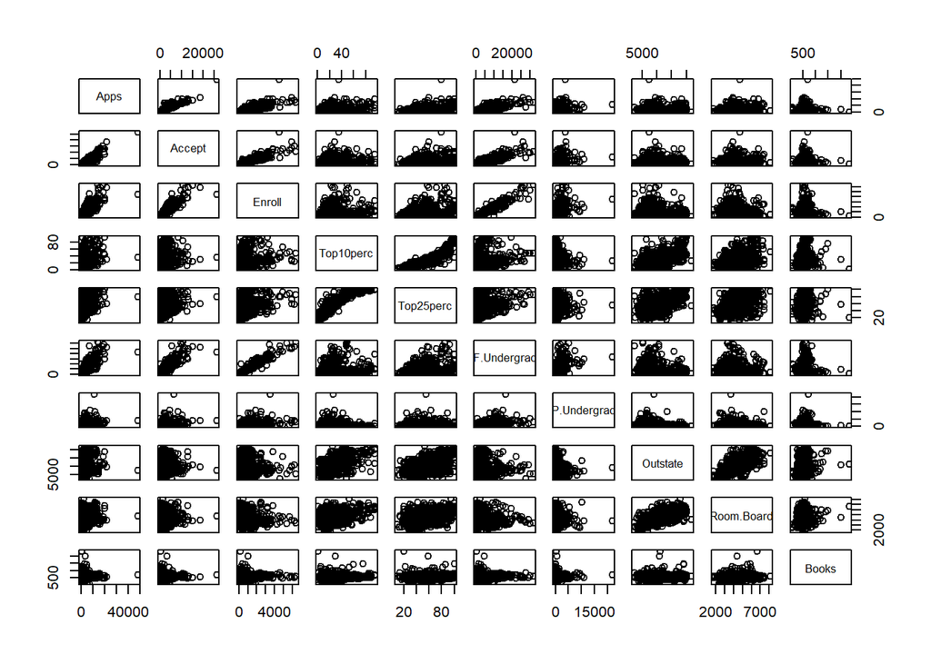

  ```r
   college_subset <- college[, 1:10]
   pairs(college_subset)
  ```

  **we can observe multi-collinearity between Accept,Enroll,F.Undergrad and Top10perc,Top20perc**
  - (iii). [3 pts] Use the `plot()` function to produce side-by-side boxplots of Outstate versus Private. Briefly state your observations.

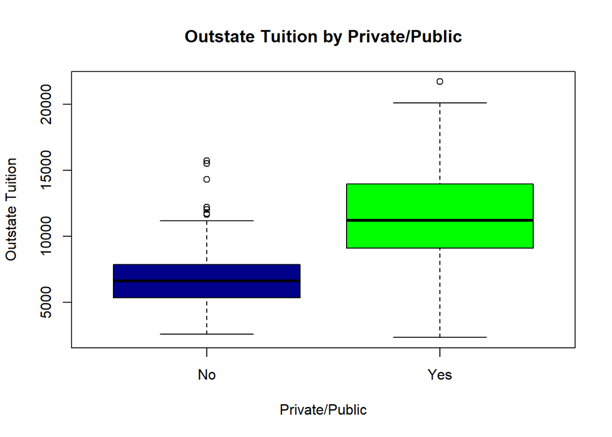

```r
boxplot(college$Outstate ~ private,
 main = "Outstate Tuition by Private/Public",
 xlab = "Private/Public",
 ylab = "Outstate Tuition",
 col = c("darkblue", "green"))
```

1.Private colleges often charge higher tuition fees for out-of-state students compared to public universities, a fact that is evident from the higher median tuition rates observed for private institutions.

2.The tuition fees at private colleges vary more widely, as shown by the larger interquartile range (IQR) on their tuition fees, indicating a greater diversity in what private universities charge compared to their public counterparts.

3.Both private and public colleges have outliers, with public colleges showing more pronounced outliers above the box plot’s upper whisker. This indicates that some public colleges charge significantly higher out-of-state tuition fees than is typical for such institutions.

4.Private institutions’ tuition fees span a broader spectrum, as illustrated by the longer whiskers on their box plot, showing that while they generally charge more, there’s considerable variability in their tuition fees.

5.The median out-of-state tuition fee at private colleges is substantially higher than that at public colleges, reinforcing the widespread belief that private education costs more than public education.

6.The box plot for private colleges is more symmetric around the median, indicating a more uniform distribution of tuition fees, whereas the plot for public universities shows a slight skew, with more data points falling towards the lower end of the tuition scale.

- (iv).[2 pts] Create a new qualitative variable, called Elite, by binning the Top10perc variable. We are going to divide universities into two groups based on whether or not the proportion of students coming from the top 10 % of their high school classes exceeds 50 %.

`> Elite <- rep("No", nrow(college))`

`> Elite[college$Top10perc > 50] <- "Yes"`

`> Elite <- as.factor(Elite)`

`> college <- data.frame(college , Elite)`

Use the `summary()` function to see how many elite universities there are. Now use the `plot()` function to produce side-by-side boxplots of Outstate versus Elite.

```r
Elite <- rep("No", nrow(college))

Elite[college$Top10perc > 50] <- "Yes"

Elite <- as.factor(Elite)

college <- data.frame(college , Elite)
summary(college)
```

```
##       Apps           Accept          Enroll       Top10perc       Top25perc
##  Min.   :   81   Min.   :   72   Min.   :  35   Min.   : 1.00   Min.   :  9.0
##  1st Qu.:  776   1st Qu.:  604   1st Qu.: 242   1st Qu.:15.00   1st Qu.: 41.0
##  Median : 1558   Median : 1110   Median : 434   Median :23.00   Median : 54.0
##  Mean   : 3002   Mean   : 2019   Mean   : 780   Mean   :27.56   Mean   : 55.8
##  3rd Qu.: 3624   3rd Qu.: 2424   3rd Qu.: 902   3rd Qu.:35.00   3rd Qu.: 69.0
##  Max.   :48094   Max.   :26330   Max.   :6392   Max.   :96.00   Max.   :100.0
##   F.Undergrad     P.Undergrad         Outstate       Room.Board
##  Min.   :  139   Min.   :    1.0   Min.   : 2340   Min.   :1780
##  1st Qu.:  992   1st Qu.:   95.0   1st Qu.: 7320   1st Qu.:3597
##  Median : 1707   Median :  353.0   Median : 9990   Median :4200
##  Mean   : 3700   Mean   :  855.3   Mean   :10441   Mean   :4358
##  3rd Qu.: 4005   3rd Qu.:  967.0   3rd Qu.:12925   3rd Qu.:5050
##  Max.   :31643   Max.   :21836.0   Max.   :21700   Max.   :8124
##      Books           Personal         PhD            Terminal
##  Min.   :  96.0   Min.   : 250   Min.   :  8.00   Min.   : 24.0
##  1st Qu.: 470.0   1st Qu.: 850   1st Qu.: 62.00   1st Qu.: 71.0
##  Median : 500.0   Median :1200   Median : 75.00   Median : 82.0
##  Mean   : 549.4   Mean   :1341   Mean   : 72.66   Mean   : 79.7
##  3rd Qu.: 600.0   3rd Qu.:1700   3rd Qu.: 85.00   3rd Qu.: 92.0
##  Max.   :2340.0   Max.   :6800   Max.   :103.00   Max.   :100.0
##    S.F.Ratio      perc.alumni        Expend        Grad.Rate      Elite
##  Min.   : 2.50   Min.   : 0.00   Min.   : 3186   Min.   : 10.00   No :699
##  1st Qu.:11.50   1st Qu.:13.00   1st Qu.: 6751   1st Qu.: 53.00   Yes: 78
##  Median :13.60   Median :21.00   Median : 8377   Median : 65.00
##  Mean   :14.09   Mean   :22.74   Mean   : 9660   Mean   : 65.46
##  3rd Qu.:16.50   3rd Qu.:31.00   3rd Qu.:10830   3rd Qu.: 78.00
##  Max.   :39.80   Max.   :64.00   Max.   :56233   Max.   :118.00
```

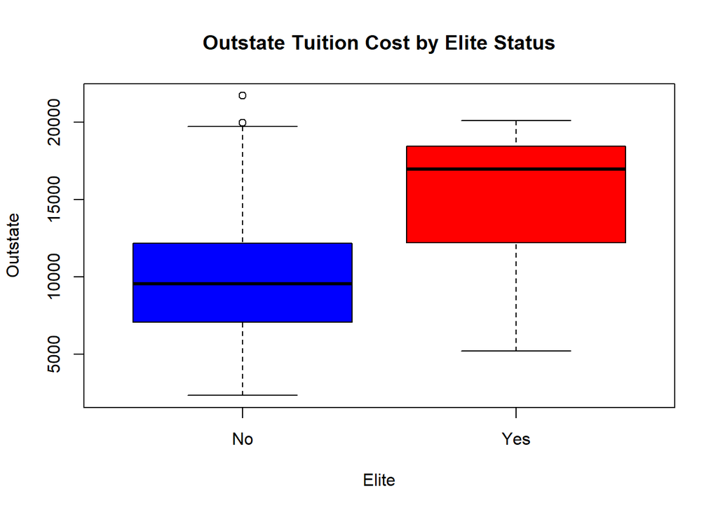

```r
plot(college$Outstate ~ college$Elite,
     main = "Outstate Tuition Cost by Elite Status",
     xlab = "Elite",
     ylab = "Outstate",
     col = c("blue", "red"))
```

- (v)[2 pts] Use the hist() function to produce some histograms with differing numbers of bins for a few of the quantitative variables. You may find the command `par(mfrow = c(2, 2))` useful: it will divide the print window into four regions so that four plots can be made simultaneously. Modifying the arguments to this function will divide the screen in other ways.

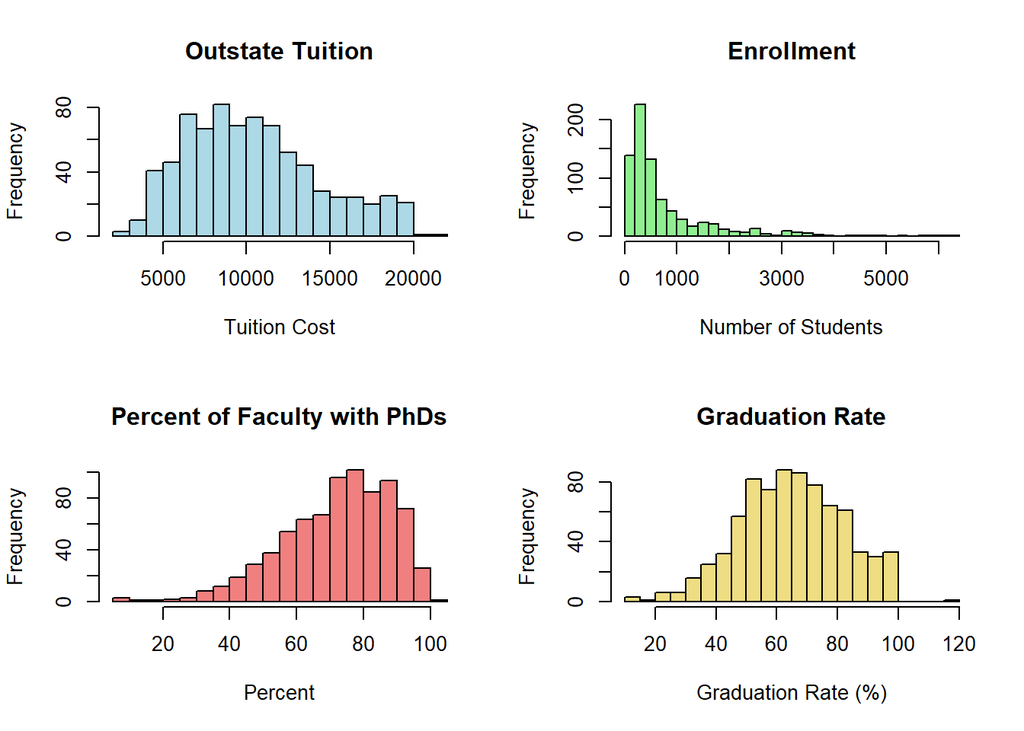

```r
par(mfrow = c(2, 2))

hist(college$Outstate, breaks = 15, main = "Outstate Tuition", xlab = "Tuition Cost", col = "lightblue")

hist(college$Enroll, breaks = 30, main = "Enrollment", xlab = "Number of Students", col = "lightgreen")

hist(college$PhD, breaks = 20, main = "Percent of Faculty with PhDs", xlab = "Percent", col = "lightcoral")

hist(college$Grad.Rate, breaks = 25, main = "Graduation Rate", xlab = "Graduation Rate (%)", col = "lightgoldenrod")
```

- (vi)[3 pts]. Continue exploring the data, and provide a brief summary of what you discover.

The above image shows four histograms, each representing a different variable.

**1.Outstate:** This histogram shows a righskewed distribution, indicating that a larger number of institutions charge lower outstate tution fees, with fewer institutions charging higher fees.The most frequent cost range appears to be between $5000 to $10000.

**2.Enroll:** This histogram is also right-skewed, suggesting that most institutions have smaller enrollment size. There is a significant drop in frequency as the number of students increases, with very few institutions having enrollment numbers above 2500 students.

**4.Graduation Rate:** This histogram appears to be approximately normally distributed, centered around the 60-80% graduation rate. This suggests that the majority of institutions have a graduation rate within this range, with fewer institutions having very low or very high graduation rates.

# Question 4 [16 pts]

This exercise involves the Boston housing data set.

- (a).[2 pts] To begin, load in the Boston data set. The Boston data set is part of the ISLR2 library.

`> library(ISLR2)`

Now the data set is contained in the object Boston.

`> Boston`

Read about the data set:

`> ?Boston`

How many rows are in this data set? How many columns? What do the rows and columns represent?

```r
library(ISLR2)
data("Boston")
head(Boston)
```

```
##      crim zn indus chas   nox    rm  age    dis rad tax ptratio lstat medv
## 1 0.00632 18  2.31    0 0.538 6.575 65.2 4.0900   1 296    15.3  4.98 24.0
## 2 0.02731  0  7.07    0 0.469 6.421 78.9 4.9671   2 242    17.8  9.14 21.6
## 3 0.02729  0  7.07    0 0.469 7.185 61.1 4.9671   2 242    17.8  4.03 34.7
## 4 0.03237  0  2.18    0 0.458 6.998 45.8 6.0622   3 222    18.7  2.94 33.4
## 5 0.06905  0  2.18    0 0.458 7.147 54.2 6.0622   3 222    18.7  5.33 36.2
## 6 0.02985  0  2.18    0 0.458 6.430 58.7 6.0622   3 222    18.7  5.21 28.7
```

```r
?Boston
```

```
## starting httpd help server ... done
```

```r
dim(Boston)
```

```
## [1] 506  13
```

**There are 506 rows and 13 columns in Boston Data Set**

- (b).[2 pts] Make some pairwise scatterplots of the predictors (columns) in this data set. Describe your findings.

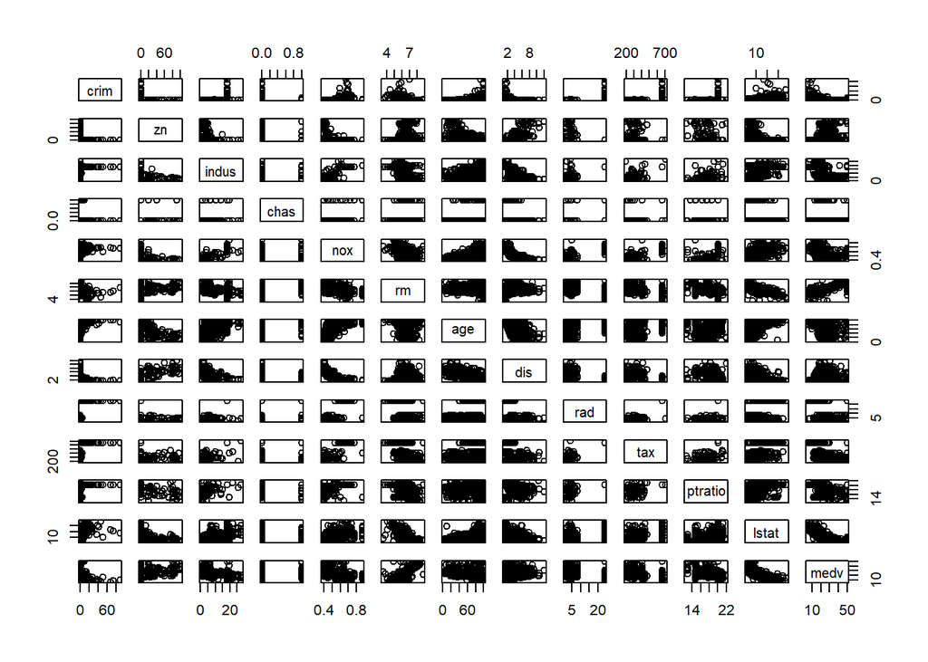

```r
pairs(Boston)
```

**1.CRIM (per capita crime rate) vs. RAD (index of accessibility to radial highways):** Areas with better accessibility to highways have a higher crime rate due to increased traffic and urban density.

**2.RM (average number of rooms per dwelling) vs. MEDV (median value of owner-occupied homes):** A positive correlation is found as homes with more rooms tend to be larger and more expensive.

**3.AGE (proportion of owner-occupied units built prior to 1940) vs. DIS (weighted distances to five Boston employment centres):** Older regions are closer to the city center, indicating a potential inverse relationship.

**4.NOX (nitric oxides concentration) vs. DIS:** There is a negative correlation, with higher pollution levels closer to employment centers and lower levels as distance increases.

**5.LSTAT (% lower status of the population) vs. MEDV:** Typically, a higher percentage of “lower status” population correlates with lower property values, so a negative correlation is observed.

**7.PTRATIO (pupil-teacher ratio by town) vs. MEDV:** A lower pupil-teacher ratio, indicating better school attention, is correlated with higher home values.

- (c).[2 pts] Are any of the predictors associated with per capita crime rate? If so, explain the relationship.

Indeed, the pairwise scatterplots from the Boston Housing Data reveal correlations between the per capita crime rate (CRIM) and various factors:

**Industrial Area Proportion (INDUS):** A positive link is observed between CRIM and INDUS, indicating that as the proportion of industrial land use in a town increases, so does the per capita crime rate. This suggests that areas with more industrial activity, which are often less residential, tend to experience higher crime rates.

**Concentration of Nitric Oxides (NOX):** The data shows a positive association between CRIM and NOX, implying that regions with higher levels of nitric oxides, indicative of pollution and potentially higher industrial presence, see increased crime rates.

**Share of Lower-Income Population (LSTAT):** A clear positive correlation exists between CRIM and LSTAT, where areas with a higher percentage of lower-income residents tend to have higher crime rates. This points to the socio-economic struggles of lower-income neighborhoods leading to more crime.

**Home Values (MEDV):** An inverse correlation is suggested between CRIM and MEDV, where higher property values are generally linked to lower crime rates. This could indicate that wealthier areas, likely with better security measures or being more residential, experience less crime.

**Proximity to Employment Centers (DIS):** A negative relationship is evident between CRIM and DIS, suggesting that areas further from job centers have lower crime rates. This may reflect the reality that central urban areas, closer to employment opportunities, have higher crime rates.

**Age of Housing (AGE):** There is a positive correlation between CRIM and AGE, indicating that older neighborhoods may face higher crime rates.

**Highway Accessibility (RAD):** A positive link is noted between CRIM and RAD, with areas that have better access to highways experiencing higher crime rates, possibly due to the increased ease of movement and potential for criminal escape. These findings contribute to a deeper understanding of the dynamics influencing crime rates in the Boston region.

- (d)[2 pts] Do any of the census tracts of Boston appear to have particularly high crime rates? Tax rates? Pupil-teacher ratios? Comment on the range of each predictor.

**Crime Rates (crim)**: There is often a wide range of crime rates with some census tracts having significantly higher rates than others. It’s not uncommon to see a few tracts with exceptionally high crime rates, which might indicate areas with potential socio-economic challenges.

**Tax Rates (tax):** The range of tax rates could also vary considerably, with some tracts having much higher rates. This might be due to differences in the fiscal needs or policies of the towns they represent.

**Pupil-Teacher Ratios (ptratio):** The pupil-teacher ratio usually varies less dramatically than crime or tax rates but still shows a range that suggests differences in educational resources or town priorities.

Considering that the median and maximum crime rate values are respectively about 0.26% and 89%, there are indeed some neighborhoods where the crime rate is alarmingly high

- (e)[1 pt] How many of the census tracts in this data set bound the Charles river?

```r
sum(Boston$chas)
```

```
## [1] 35
```

[output not shown]

- (f)[1 pt] What is the median pupil-teacher ratio among the towns in this data set?

```r
median(Boston$ptratio)
```

```
## [1] 19.05
```

**The median pupil-teacher ratio among the towns in the Boston housing data set is 19.05**

- (g)[3 pts] Which census tract of Boston has lowest median value of owneroccupied homes? What are the values of the other predictors for that census tract, and how do those values compare to the overall ranges for those predictors? Comment on your findings.

```r
Boston[which.min(Boston$medv),]
```

```
##        crim zn indus chas   nox    rm age    dis rad tax ptratio lstat medv
## 399 38.3518  0  18.1    0 0.693 5.453 100 1.4896  24 666    20.2 30.59    5
```

```r
summary(Boston)
```

```
##       crim                zn             indus            chas
##  Min.   : 0.00632   Min.   :  0.00   Min.   : 0.46   Min.   :0.00000
##  1st Qu.: 0.08205   1st Qu.:  0.00   1st Qu.: 5.19   1st Qu.:0.00000
##  Median : 0.25651   Median :  0.00   Median : 9.69   Median :0.00000
##  Mean   : 3.61352   Mean   : 11.36   Mean   :11.14   Mean   :0.06917
##  3rd Qu.: 3.67708   3rd Qu.: 12.50   3rd Qu.:18.10   3rd Qu.:0.00000
##  Max.   :88.97620   Max.   :100.00   Max.   :27.74   Max.   :1.00000
##       nox               rm             age              dis
##  Min.   :0.3850   Min.   :3.561   Min.   :  2.90   Min.   : 1.130
##  1st Qu.:0.4490   1st Qu.:5.886   1st Qu.: 45.02   1st Qu.: 2.100
##  Median :0.5380   Median :6.208   Median : 77.50   Median : 3.207
##  Mean   :0.5547   Mean   :6.285   Mean   : 68.57   Mean   : 3.795
##  3rd Qu.:0.6240   3rd Qu.:6.623   3rd Qu.: 94.08   3rd Qu.: 5.188
##  Max.   :0.8710   Max.   :8.780   Max.   :100.00   Max.   :12.127
##       rad              tax           ptratio          lstat
##  Min.   : 1.000   Min.   :187.0   Min.   :12.60   Min.   : 1.73
##  1st Qu.: 4.000   1st Qu.:279.0   1st Qu.:17.40   1st Qu.: 6.95
##  Median : 5.000   Median :330.0   Median :19.05   Median :11.36
##  Mean   : 9.549   Mean   :408.2   Mean   :18.46   Mean   :12.65
##  3rd Qu.:24.000   3rd Qu.:666.0   3rd Qu.:20.20   3rd Qu.:16.95
##  Max.   :24.000   Max.   :711.0   Max.   :22.00   Max.   :37.97
##       medv
##  Min.   : 5.00
##  1st Qu.:17.02
##  Median :21.20
##  Mean   :22.53
##  3rd Qu.:25.00
##  Max.   :50.00
```

**The CRIM metric**, reflecting the crime rate, allows for comparison of a specific tract’s crime level against the overall span from 0.00632 to 88.97620. Values nearing the upper limit suggest a higher likelihood of being a high-crime area.

**For ZN**, the proportion of residential land zoned for larger lots, values at 0 or near it indicate minimal large-lot residential zoning, potentially affecting property values.

**A higher INDUS figure**, approaching the maximum of 27.74, denotes a predominantly industrial area, potentially impacting the quality of living.

**The CHAS variable**, indicating proximity to the Charles River (1 for yes), can influence real estate prices due to location desirability.

**Elevated NOX levels**, near the high end of its range, may point to inferior air quality, often a result of industrial emissions.

**Lower counts of RM**, particularly close to the bottom of its range, hint at smaller dwellings, usually associated with lower median home values.

**An increased AGE** value signals a preponderance of older, owner-occupied housing, affecting property values based on the appeal and condition of such homes.

**DIS values**, reflecting weighted distances to employment centers, with lower figures can suggest closeness to job centers but may also indicate potential for urban density issues.

**High RAD scores**, indicating greater access to radial highways, could influence desirability either positively or negatively, depending on traffic and noise levels.

**Elevated TAX figures**, particularly near their peak, imply higher property tax rates, potentially indicative of greater local government spending and possibly better area services.

**A high PTRATIO**, especially at or close to its maximum, may indicate larger classroom sizes, which could be a marker for the educational quality.

**Lastly, an increased LSTAT** percentage points to a higher portion of lower-income residents, typically linked with reduced home values.

- (h)[3 pts] In this data set, how many of the census tracts average more than seven rooms per dwelling? More than eight rooms per dwelling? Comment on the census tracts that average more than eight rooms per dwelling.

```r
sum(Boston$rm > 7)
```

```
## [1] 64
```

```r
sum(Boston$rm > 8)
```

```
## [1] 13
```

In the dataset, 64 census tracts are characterized by an average dwelling size of more than 7 rooms, indicating a considerable segment of the dataset consists of relatively large homes. This characteristic suggests these areas may have higher living standards, as larger homes often accommodate bigger families or wealthier individuals, potentially leading to higher property values due to the appeal of spacious living areas.

A more select group of 13 census tracts has homes averaging more than 8 rooms, indicating even larger and potentially more luxurious living spaces. These homes might be historic or located in highly sought-after areas, representing the pinnacle of housing in terms of size and possibly quality within the dataset.

Census tracts with homes averaging over eight rooms are particularly significant for various reasons:

**Affluence and Desirability:** These areas are likely among the most affluent, with larger homes typically being more costly and situated in coveted neighborhoods. They may feature extensive amenities, sizable plots, and more privacy.

**Property Values:** A higher average room count suggests these areas boast higher median property values. Larger homes not only provide more space but are often built with superior materials and features, enhancing their value.

**Community Characteristics:** Communities with such spacious homes are likely to have lower population densities, abundant greenery, and possibly reduced crime rates, all contributing to an enhanced living quality and neighborhood appeal.

**Educational and Local Services:** These areas may benefit from well-funded services, such as schools and recreational facilities, thanks to the higher property taxes collected from the more valuable homes.

**Historical Significance:** Some of these larger homes may have historical value, adding to their allure. However, this could also mean they require more maintenance and preservation efforts.

Overall, the census tracts with dwellings averaging more than eight rooms likely stand out as the most prestigious and sought-after residential areas in the Boston dataset. They shed light on wealth distribution and housing quality within the region, underlining disparities in living standards across various communities. This information is valuable for research in urban planning, real estate development, and policy-making aimed at mitigating housing inequality.

# Question 5. [6 pts]

Suppose we have a data set with five predictors, $X1 = \text{GPA}, X2 =IQ, X3 = \text{Level (1 for College and 0 for High School)}, X4 =\text{Interaction between GPA and IQ, and }X5 = \text{Interaction between GPA and Level.}$ The response is starting salary after graduation (in thousands of dollars). Suppose we use least squares to fit the model, and get $\hat{\beta}_0 = 50, \hat{\beta}_1 = 20, \hat{\beta}_2 = 0.07, \hat{\beta}_3 = 35, \hat{\beta}_4 = 0.01, \hat{\beta}_5 = −10$.

- (a)[3 pts] Predict the salary of a college graduate with IQ of $110$ and a GPA of $4.0$.

```r
beta0 = 50
beta1 = 20
beta2 = 0.07
beta3 = 35
beta4 = 0.01
beta5 = -10

X1 = 4.0  # GPA
X2 = 110  # IQ
X3 = 1    # Level (College)
X4 = X1 * X2  # Interaction between GPA and IQ
X5 = X1 * X3  # Interaction between GPA and Level

predicted_salary = beta0 + beta1*X1 + beta2*X2 + beta3*X3 + beta4*X4 + beta5*X5

predicted_salary
```

```
## [1] 137.1
```

- (b)[3 pts] True or false: Since the coefficient for the GPA/IQ interaction term is very small, there is very little evidence of an interaction effect. Justify your answer.

**False.** The size of the coefficient for the GPA/IQ interaction term by itself does not directly indicate the strength or evidence of an interaction effect in a regression model. The significance of an interaction effect is determined by its statistical significance, typically assessed through a hypothesis test (e.g., t-test) and evidenced by its p-value, rather than the magnitude of the coefficient alone.

A small coefficient may still have a significant impact if it is statistically significant, meaning that the probability of observing such an effect by chance is low. Statistical significance is influenced by the sample size, variability of the data, and the scale of the predictors. Therefore, even a small coefficient can be meaningful and indicate a real interaction effect if it is statistically significant